# Encontros relâmpagos

```r
library(GGally)
library(tidyverse)
library(openintro)
library(modelr)
library(here)
library(readr)
library(resample)
library(broom)
theme_set(theme_bw())
```

Para esse checkpoint, iremos utilizar dados de encontros relâmpagos e a impressão que as pessoas tiveram uma das outras depois desse date e quais características físicas e de personalidade atraiam-as. Primeiramente, vamos importar os dados:

```r
encontros = read_csv(here("data/speed-dating.csv"))
```

### Então, o que faz uma pessoa gostar de outra?

Selecionei algumas variáveis disponíveis no csv para encontrar uma possível resposta.

- Like: no geral, quanto p1 gostou de p2?
- Attr: quão atraente p1 achou p2
- Sinc: quão sincero p1 achou p2
- Fun: quão divertido p1 achou p2
- Prob: que probabiliade p1 acha que p2 tem de querer se encontrar novamente com p- (escala 1-10)
- Intel: quão inteligente p1 achou p2
- Int_corr: correlação entre os interesses de p1 e p2
- Shar: quanto p1 achou que compartilha interesses e hobbies com p2

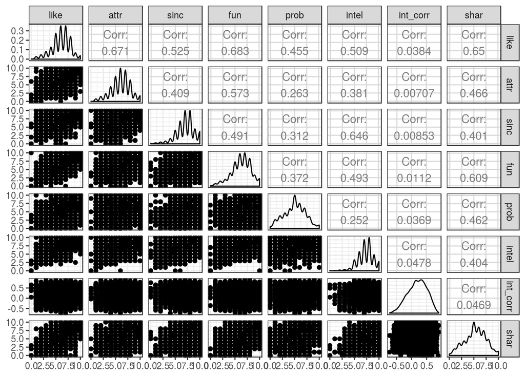

```r
encontros %>%
  select(like,
         attr,
         sinc,
         fun,
         prob,
         intel,
         int_corr,
         shar) %>%
  ggpairs(progress=FALSE)
```

A partir dessa observação, podemos ver que attr(atraência) e fun(divertida) tiveram resultados altos de correlação e por isso as escolhi para utilizá-las no modelo para o questiomento feito anteriormente.

```r
escolhidas <- encontros %>%
  select(like,
         fun,
         attr) %>%
  na.omit(.)
```

```r
md_like = lm(like ~ fun + attr, data = escolhidas)
tidy(md_like, conf.int = TRUE)
```

```
##          term  estimate  std.error statistic       p.value  conf.low
## 1 (Intercept) 1.0391152 0.06416500  16.19442  1.931667e-57 0.9133217
## 2         fun 0.4153587 0.01073226  38.70190 1.095440e-284 0.3943184
## 3        attr 0.3948057 0.01094067  36.08607 6.266414e-252 0.3733569
##   conf.high
## 1 1.1649087
## 2 0.4363989
## 3 0.4162546
```

```r
glance(md_like, conf.ini = TRUE)
```

```
##   r.squared adj.r.squared    sigma statistic p.value df    logLik     AIC
## 1 0.5826971     0.5825195 1.190388  3281.401       0  3 -7491.402 14990.8
##        BIC deviance df.residual
## 1 15016.63 6660.009        4700
```

As informações acima podemos explorar a medida do R quadrado, sendo ela:

R quadrado: representa a porcentagem de variação na resposta que é explicada pelo modelo.

Então, a partir dessa definições podemos realizar algumas conclusões. No R quadrado, temos o valor de aproximadamente 0.58, e quanto maior esse valor, melhor o modelo se ajusta nos dados.

Depois de decoberto os dados e tiradas as conclusões acima, iremos gerar a visualização do modelo.

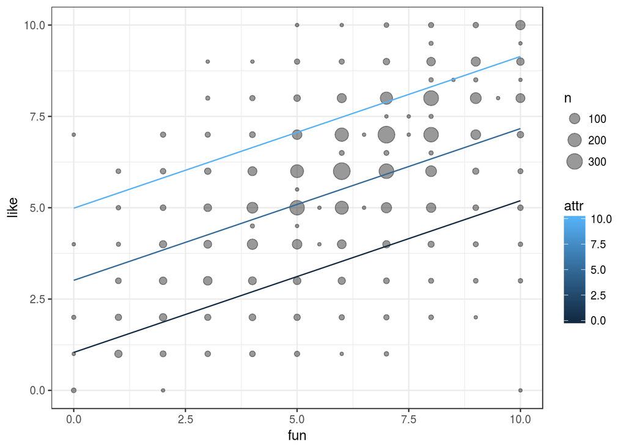

```r
b <- encontros %>%
  data_grid(attr=seq_range(attr, 3),
            fun=seq_range(fun, 3)) %>%
  add_predictions(model=md_like)

encontros %>%
  ggplot(mapping = aes(x = fun,
                       y = like)) +
  geom_count(alpha=.4) +
  geom_line(data = b, aes(y=pred, group=attr, color=attr)) +
  geom_abline(intercept = 69, slope = -.65, color='red')
```

Como visto acima, podemos ver que as características que escolhemos influenciam na variável like. No eixo x, temos o quão divertida é a pessoa e as linhas inclinadas representam o quão a atraência influencia no like, representado no eixo y. Dessa forma, podemos observar que entre os intervalos de 5 e 7.5, possuem uma maior concentração de resultados para as duas variáveis.